# R Notebook

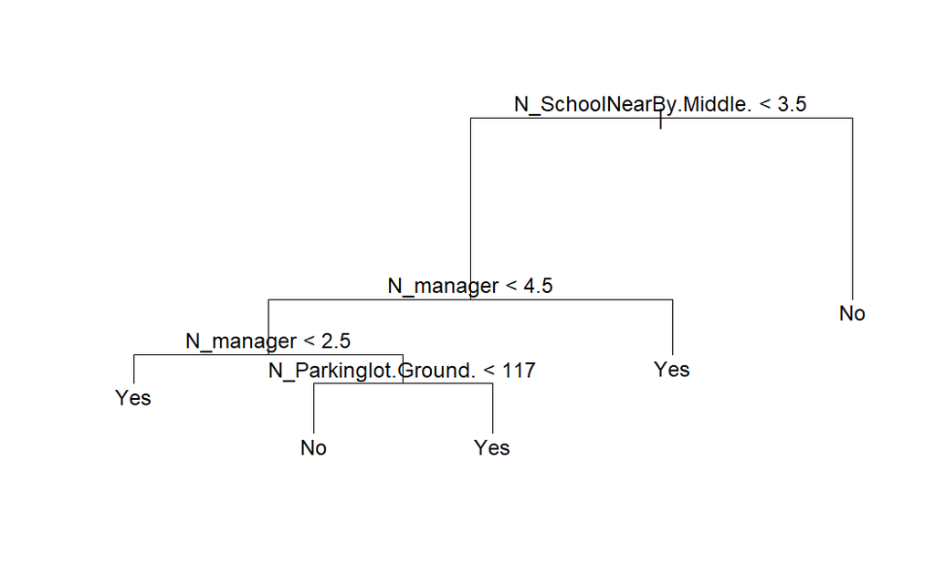

```r
plot(IS_elevator_tree)
text(IS_elevator_tree, pretty = 0)
```

```r
print(IS_elevator_tree)
```

```
node), split, n, deviance, yval, (yprob)
      * denotes terminal node

 1) root 4123 3932.0 Yes ( 0.18360 0.81640 )
   2) N_SchoolNearBy.Middle. < 3.5 3589 1671.0 Yes ( 0.06213 0.93787 )
     4) N_manager < 4.5 848  977.1 Yes ( 0.26297 0.73703 )
       8) N_manager < 2.5 400    0.0 Yes ( 0.00000 1.00000 ) *
       9) N_manager > 2.5 448  621.1 Yes ( 0.49777 0.50223 )
        18) N_Parkinglot.Ground. < 117 223    0.0 No ( 1.00000 0.00000 ) *
        19) N_Parkinglot.Ground. > 117 225    0.0 Yes ( 0.00000 1.00000 ) *
     5) N_manager > 4.5 2741    0.0 Yes ( 0.00000 1.00000 ) *
   3) N_SchoolNearBy.Middle. > 3.5 534    0.0 No ( 1.00000 0.00000 ) *
```

```r
library(tree)
predictions <- predict(IS_elevator_tree, test_data, type = "class")
confusionMatrix(predictions, test_data$IS_elevator)
```

```
Confusion Matrix and Statistics

          Reference
Prediction   No  Yes
       No   305    0
       Yes    0 1463

               Accuracy : 1
                 95% CI : (0.9979, 1)
    No Information Rate : 0.8275
    P-Value [Acc > NIR] : < 2.2e-16

                  Kappa : 1

 Mcnemar's Test P-Value : NA

            Sensitivity : 1.0000
            Specificity : 1.0000
         Pos Pred Value : 1.0000
         Neg Pred Value : 1.0000
             Prevalence : 0.1725
         Detection Rate : 0.1725
   Detection Prevalence : 0.1725
      Balanced Accuracy : 1.0000

       'Positive' Class : No
```

Uzyskany model drzewa decyzyjnego użył do budowy drzewa tylko następujące zmienne:“N_SchoolNearBy.Middle.”, “N_manager”, N_Parkinglot.Ground.”. I są to zmienne które są najbardziej istotne w klasyfikacji tego czy winda istnieje w budynku. Uzyskane wyniki wskazują na idelane dopasowanie do danych, i bezbłędne rozpoznanie wszystkich klas w zbiorze testowym. Wynik ten jednak wydaje się być niemożliwym do uzyskania w rzeczywistiści. Upatrujemy przyczyne w zbiorze danych i być może zbyt małej ilości rekorów danych, rónież nie równym podziale w kategorii jest/nie ma windy.

Las losowy:

```r
install.packages("randomForest") # Install the package
library(randomForest) # Load the package
```

```r
# Train the random forest model
rf_model <- randomForest(IS_elevator ~  YearBuilt + YrSold + MonthSold + Size.sqf. + Floor
                      +N_Parkinglot.Ground. + N_Parkinglot.Basement. + N_APT+ N_manager  + N_FacilitiesNearBy.PublicOffice. + N_FacilitiesNearBy.Hospital. + N_FacilitiesNearBy.Dpartmentstore. + N_FacilitiesNearBy.Mall. + N_FacilitiesNearBy.ETC. + N_FacilitiesNearBy.Park. + N_SchoolNearBy.Elementary. + N_SchoolNearBy.Middle. + N_SchoolNearBy.High. + N_SchoolNearBy.University. + N_FacilitiesInApt + N_FacilitiesNearBy.Total. + N_SchoolNearBy.Total. + HallwayTypemixed + HallwayTypeterraced + HeatingTypeindividual_heating + AptManageTypeself_management + SubwayStationBanwoldang + SubwayStationDaegu + SubwayStationKyungbuk_uni_hospital +  SubwayStationno_subway_nearby, data = train_data, ntree = 50, mtry = 6)
```

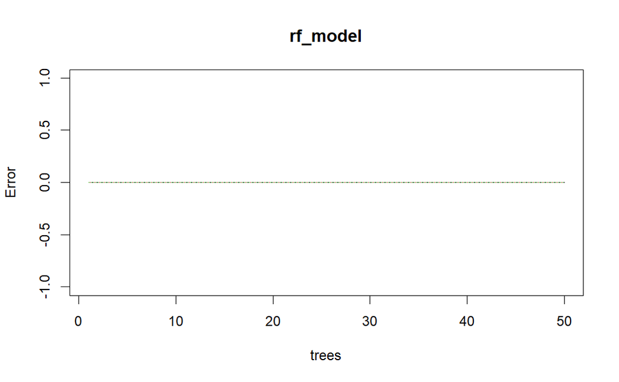

```r
# Plot the error vs the number of trees graph
plot(rf_model)
```

```r
predictions <- predict(rf_model, test_data, type = "class")

# Ocenianie dopasowania modelu
confusion_matrix <- confusionMatrix(predictions, test_data$IS_elevator)
accuracy <- confusion_matrix$overall['Accuracy']
precision <- confusion_matrix$byClass['Precision']
recall <- confusion_matrix$byClass['Recall']
specificity <- confusion_matrix$byClass['Specificity']
f1_score <- confusion_matrix$byClass['F1']

# Wyświetlenie wyników
print(confusion_matrix)
```

```
Confusion Matrix and Statistics

          Reference
Prediction   No  Yes
       No   305    0
       Yes    0 1463

               Accuracy : 1
                 95% CI : (0.9979, 1)
    No Information Rate : 0.8275
    P-Value [Acc > NIR] : < 2.2e-16

                  Kappa : 1

 Mcnemar's Test P-Value : NA

            Sensitivity : 1.0000
            Specificity : 1.0000
         Pos Pred Value : 1.0000
         Neg Pred Value : 1.0000
             Prevalence : 0.1725
         Detection Rate : 0.1725
   Detection Prevalence : 0.1725
      Balanced Accuracy : 1.0000

       'Positive' Class : No
```

```r
cat(paste0("Accuracy: ", accuracy, "\n"))
```

```
Accuracy: 1
```

```r
cat(paste0("Precision: ", precision, "\n"))
```

```
Precision: 1
```

```r
cat(paste0("Recall: ", recall, "\n"))
```

```
Recall: 1
```

```r
cat(paste0("Specificity: ", specificity, "\n"))
```

```
Specificity: 1
```

```r
cat(paste0("F1 Score: ", f1_score, "\n"))
```

```
F1 Score: 1
```

Wyniki lasu losowego są takie podobne do pojedynczego drzewa. Idelane dopasowanie do danych, poprawne przewidzenie wszystkich przykłądów. Jak zostało wspomniane wcześniej, wynik taki wydaje się być zbyt idelany, uaptrujemy winy w danych, (zbyt mała ilość danych, zbyt duża dysproporcja w klasie (ilość) yes/no)